# biofp

Functional programming principles can be productively applied even in small cases. The predictability and compositional capacity of small functions allows for modular, extensible code. First-order functions can be used in a variety of generic higher-order functions or "combinators". In the future, we will look at how static typing combined with immutability can make this code much safer as an additional benefit.

Let's use calculating GC-content as an example.

Where `seq` is some DNA sequence--just a string of characters composed soley of items in the set `{'A', 'C', 'G', 'T'}`

```python
def gc(seq):
    '''(G+C)/(A+T+G+C) * 100'''
    return (seq.count('G') + seq.count('C')) / float( len(seq) )
print(gc("ACGTCCA"))
```

```
0.571428571429
```

But reall, we want to model GC-content as a fraction, so at any given time we know the size of the sequence. Python has a fraction class, but it doesn't allow us to represent the state `0/0`, which would be our startin state.

```python
from fractions import Fraction
class Ratio(Fraction):
    ''' new is for immutable classes.'''
    def __new__(cls, num, denom):
        '''cls is like self really '''
        if denom ==0 and num == 0:
            self = super(Fraction, cls).__new__(cls)
        else:
            self = super(Fraction, cls).__new__(cls)
        self.__str__ = Ratio.__str__
        self._numerator, self._denominator = num, denom
        return self
    def __float__(self):
        if self._denominator == 0:
            return 0.0
        else:
            return super(Fraction, self).__float__()

    def __str__(self):
        return "{0}/{1}".format(self._numerator, self._denominator)
```

Now we can update our function:

```python
def gc(seq):
    '''(G+C)/(A+T+G+C) * 100'''
    return Ratio(seq.count('G') + seq.count('C'),  len(seq))
print(gc("ACGTCCA"))
```

```
4/7
```

'This is all well and good, but what if we want to know the GC-content at a certain place in the read?

```python
seq = 'AGCTTAGGCCTTTAAAACCGGGGCCCCCGGAAGCGACTT'
print gc(seq[:10])
```

```
6/10
```

That works, but will get tiresome and inefficient...

```python
gc(seq[0]), gc(seq[:10]), gc(seq[-1])
```

```
(Fraction(0, 1), Fraction(6, 10), Fraction(0, 1))
```

What if we want to create a histogram of the gc-content at each position in the read?

```python
N = len(seq)
def gc_hist_(seq):
    return [gc_counter(seq[:i]) for i  in xrange(1, N)]
```

we have to re-calculate the GC-ratio each time! In terms of runtime, this is equivalent to:

```python
sum(i for i in xrange(N) )
```

```
741
```

Well, this method is O(N^2) (about (N^2)/2, where N=length of sequence). So the runtime is quadratic. We can fix this by writing a new function specifially for constructing a list of GC-content.

Instead, let's try solving this problem with higher-order functions, and see where that gets us.

Functional programming works well when we compose small functions together. Let's create the smallest unit we can out of this problem:

```python
def content(ratio, nt):
    val = 1 if nt in 'GC' else 0
    return Ratio(ratio.numerator + val, ratio.denominator+1)
```

Next, let's solve our problem of creating a rolling GC-content for a histogram using a higher-order function and `content`. A higher-order function is just a function which accepts another function as one of its arguments. This feature isn't available in all programming languages, but it's available in python. The higher-order function we'll use is `accumulate`.

In haskell, accumulate is known as `scanl`, and it's corrolary is `foldl`. `accumulate` is similar to `reduce` in python, except it keeps track of every result, rather than throwing them away and only keeping the final result.

```python
def accumulate(iterable, func, start=None):
    '''re-implementation of accumulate that allows you to specify a start value
    like with reduce.'''
    it = iter(iterable)
    if start is None:
        total = next(it)
        yield total
    else:
        total = start
    #could also skip yielding total
    for element in it:
        total = func(total, element)
        yield total

import operator
print list(accumulate([1,2,3,4,5], operator.mul)) # --> 1 2 6 24 120
print list(accumulate("ACGCCGT", content, Ratio(0, 0)))
from functools import partial
func_gc_hist = partial(accumulate, func=content, start=Ratio(0,0))
```

```
[1, 2, 6, 24, 120]
[Fraction(0, 1), Fraction(1, 2), Fraction(2, 3), Fraction(3, 4), Fraction(4, 5), Fraction(5, 6), Fraction(5, 7)]
```

Now we have our histogram! Let's look more closely at how this works using `reduce` as an example. Using our function `content` with `reduce` will give us the total GC-ratio for a given sequence. `reduce` emulates recursion by computing a new value for each element in the list and passing it onto the next call with the element as a paramter. Let's look at a simple example of summing a list:

```python
def _add2(acc, elem):
    return elem + acc

print reduce(_add2, [1,2,3,4,5])
```

```
15
```

Let's break this down, step by step. Here, each line represents an iteration of reduce. . . .

```
# under the hood, this might look like:
[1, 2, 3], 0
-> [1, 2], 3
-> [1],   5
>>>6
```

In a sense `reduce` is "substituting" parts of the list for there sum, similar to how one might simplify an algabreic equation. We can see this pattern in accumulate's output:

```python
print list(accumulate([1,2,3,4,5], _add2))
```

```
[1, 3, 6, 10, 15]
```

```
Another simple example, reversing a list. list reversal has a straightforward recursive solution:
```

```python
def _reverse(l):
    if len(l) == 0: return []
    return [l[-1]] + _reverse(l[:-1])
print(_reverse([1, 2, 3, 4]))
```

```
[4, 3, 2, 1]
```

But it can be written much more simply using `reduce`, which handles the details of the recursive call.

```python
def _reverse(acc, elem):
    return [elem] + acc
reduce(_reverse, [1,2,3,4], [])
```

```
[4, 3, 2, 1]
```

Again, let's break it down:

```
[1, 2, 3, 4], []
-> [1, 2, 3], [4]
-> [1, 2],    [4, 3]
-> [1],       [4, 3, 2]
>>>[4, 3, 2, 1]
```

notice that at any point during the traversal, the accumulated value is correct for the traversed part of the list. Using this model of folding an accumulating paramter over a sequence, we can model GC-content as a "rolling ratio" over a given sequence of nucleotides. At any point during the traversal, The ratio will be correct, and the result of "reducing" the sequence with this model will give us our total GC-content. The following method is not the most efficient nor the simplest (it requires building a "Ratio" subclass), but it closely (and flexibly) models the mathematical formula that defines GC-content in the first place. '''

```python
seq = 'AGCTTAGGCCTTTAAAACCGGGGCCCCCGGAAGCGACTT'
print reduce(content, seq, Ratio(0,0))
```

```
23/39
```

That's all reasonable, and it's nice to see GC-content representated as a ratio. But is it practical? Well, it will work, but there is a much more efficient way. Array-wise computations like this--which will become quite large if we get big reads (or god forbid) a whole contig/genome. Additionally, we may want to scale to viewing multiple reads at once, ie, as a matrix.

```python
from random import choice
N = 1000000
alpha = list('AGCT')
seq = ''.join( choice(alpha) for _ in xrange(N) )
from fn.iters import repeatfunc
seq = ''.join(repeatfunc(partial(choice, alpha), N))
%timeit functional = func_gc_hist(seq)
```

```
The slowest run took 4.67 times longer than the fastest. This could mean that an intermediate result is being cached
1000000 loops, best of 3: 663 ns per loop
```

```python
import numpy as np
np.array([1, 2, 3, 4, 5]).sum()
```

```
15
```

`np.sum` is actually a specific (read: partial application) of np.reduce! [source](https://github.com/numpy/numpy/blob/a9c810dd1d8fc1e3c6d0f0ca6310f41795545ec9/numpy/core/_methods.py)

```python
npseq = np.array(list(seq))
gccon = ((npseq == 'C') | (npseq == 'G')).sum()/float(len(npseq))
npresult = ((npseq == 'C') | (npseq == 'G')).cumsum()
```

cumulative sum rolls like accumulate!

Now, we'll divide by the index (starting at one) to simulate the ratio.

```python
gcs = ((npseq == 'C') | (npseq == 'G'))
npres = gcs.cumsum()/np.arange(1,len(npresult)+1, dtype=float)
np_filter_idx = (npres >= .5).nonzero()
```

Putting this together:

```python
def np_gc_hist(seq):
     npseq = np.array(list(seq))
     gcs = ((npseq == 'C') | (npseq == 'G'))
     npres = gcs.cumsum()/np.arange(1,len(gcs)+1, dtype=float)
     return npres
```

Let's plot it:

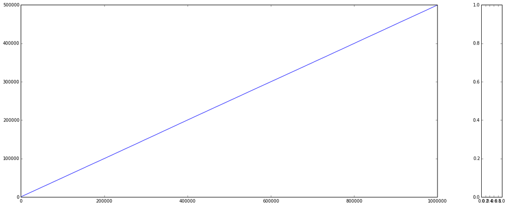

```python
import matplotlib
from matplotlib import pyplot as plt
%pylab inline
THRESH=0.4
def doplot(result):
    fig = plt.figure()
    fig.set_size_inches( 20.0, 8.0 )
    gs = matplotlib.gridspec.GridSpec(1,2, width_ratios=[20,1])
    ax1 = plt.subplot(gs[0])
    ax2 = plt.subplot(gs[1])
    ax1.plot(result)
    '''draw a line for the threshold.'''
    ax1.axhline(y=THRESH, color='green')
    fig.show()
doplot(npresult)
```

Let's try timing again. First, our old result:

```python
%timeit imperative = list(gc_hist(seq))
```

[output not shown]

Now with numpy:

```python
%timeit numpy_sttyle = np_gc_hist(seq)
```

```
10 loops, best of 3: 140 ms per loop
```